# Linguist List Job Scraping Tool

Jesse Harris

May 20, 2017

# Documentation

Use this R Markdown to scrape Linguist List for job trends with the following libraries:

- magrittr
- stringr
- rvest
- tidyr
- ggplot2
- gsubfn
- htmlTable

Use the code and as you like, but please just give a shout out if you use this script. **Comments are most welcome!**

The script is maintained on a githib repository [here](https://github.com/jaharris/linglist-scrape).

### Methodology

The script downloads the Linguist List job posting [archives](http://linguistlist.org/jobs/browse-previous-jobs2.cfm) for the years specified below. After some reformatting, it removes all but tenture track job postings and categorizes the jobs according to keywords listed in the posting. The method for categorization largely follows previous efforts by Chris Potts, Heidi Harley, Stephanie Shih, and Rebacca Starr (see the Language Log postings on the [2008 data](http://languagelog.ldc.upenn.edu/nll/?p=1067), [2009 data](http://languagelog.ldc.upenn.edu/nll/?p=1491), and [2009-2012 data](http://languagelog.ldc.upenn.edu/nll/?p=4349)).

Fields currently reported are limted to phonetics, phonology, morphology, syntax, semantics, historical, sociolinguistics, psycholinguistics, langcog, and computational linguistics, essentially following the procedure discused [here](http://languagelog.ldc.upenn.edu/nll/?p=4349).

**Important caveat:** The numbers reported here have been compiled without reading the actual post, and are limited to the keywords listed in the post itself. I make no claims regarding the accuracy of the categorization. In addition, some job postings may classified within multiple fields (e.g., syntax and morphology), leading to double counting.

### Output

Two kinds of files are produced by the script: data files in csv format, and plots in pdf format.

##### Data

The script produces three csv files with data from the period of interest:

1. All the jobs data after post-processing (including the original job listing),
2. All the tenure track jobs in the fields of interest, and
3. A basic summary of the number of jobs listed per year in each field.

##### Plots

The script outputs a plot summarizing the average number of jobs posted for each field and a plot showing how many jobs were advertised in a single year. Plots are printed directly to pdf format.

### Set dates here

Enter dates to search here. Set to search Linguist List from 2004 to 2016.

**NB.** Start date cannot be before 2000. Note also that there are very few job advertisements before 2004.The remainder of the script should run without additional input.

### Tenure track job listings from 2004 to 2016.

| Average number of jobs posted in period by year. | Average number of jobs posted in period by year. 2004 | Average number of jobs posted in period by year. 2005 | Average number of jobs posted in period by year. 2006 | Average number of jobs posted in period by year. 2007 | Average number of jobs posted in period by year. 2008 | Average number of jobs posted in period by year. 2009 | Average number of jobs posted in period by year. 2010 | Average number of jobs posted in period by year. 2011 | Average number of jobs posted in period by year. 2012 | Average number of jobs posted in period by year. 2013 | Average number of jobs posted in period by year. 2014 | Average number of jobs posted in period by year. 2015 | Average number of jobs posted in period by year. 2016 | Average number of jobs posted in period by year. Total |
| --- | --- | --- | --- | --- | --- | --- | --- | --- | --- | --- | --- | --- | --- | --- |
| phonetics | 2 | 8 | 11 | 7 | 8 | 4 | 6 | 6 | 13 | 12 | 7 | 15 | 8 | 107 |
| phonology | 4 | 18 | 11 | 9 | 10 | 8 | 14 | 15 | 17 | 17 | 8 | 20 | 19 | 170 |
| morphology | 0 | 1 | 1 | 1 | 0 | 2 | 3 | 0 | 2 | 5 | 3 | 4 | 5 | 27 |
| syntax | 4 | 10 | 16 | 8 | 14 | 11 | 16 | 6 | 12 | 17 | 9 | 16 | 11 | 150 |
| semantics | 5 | 9 | 5 | 6 | 5 | 9 | 6 | 5 | 11 | 9 | 7 | 4 | 9 | 90 |
| historical | 1 | 2 | 2 | 3 | 5 | 2 | 2 | 3 | 3 | 6 | 2 | 1 | 5 | 37 |
| sociolinguistics | 7 | 16 | 16 | 14 | 11 | 10 | 13 | 13 | 15 | 17 | 14 | 25 | 24 | 195 |
| psycholinguistics | 6 | 4 | 5 | 2 | 6 | 4 | 4 | 8 | 8 | 13 | 3 | 14 | 15 | 92 |
| langcog | 1 | 4 | 2 | 1 | 5 | 4 | 4 | 7 | 5 | 8 | 3 | 8 | 3 | 55 |
| computational | 9 | 10 | 5 | 9 | 6 | 4 | 7 | 6 | 7 | 11 | 2 | 15 | 17 | 108 |
| Total | 39 | 82 | 74 | 60 | 70 | 58 | 75 | 69 | 93 | 115 | 58 | 122 | 116 | 1031 |

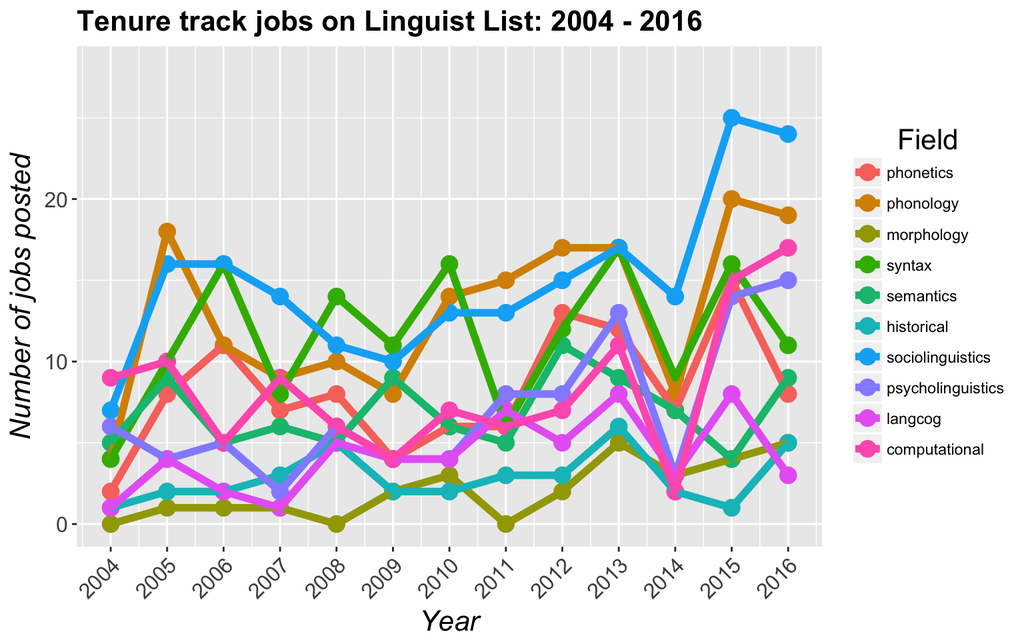

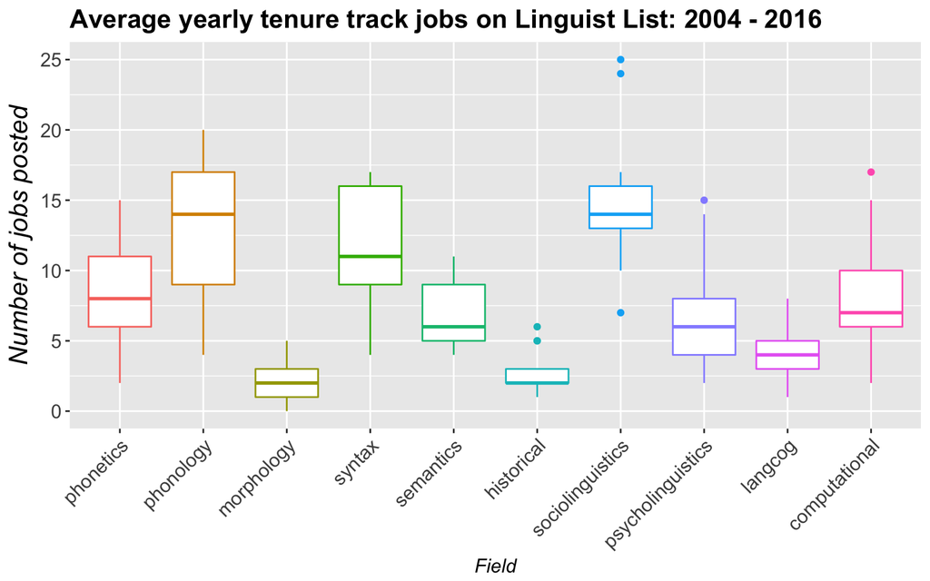